# Census Data Wrangling and Mapping in R - Tutorial

## Fetching Multiple ACS-5 Variables

First identify the variables of interest.

```r
# Median household income by race/ethnicity: Variables from ACS 2015—19
#All households =   "B19013_001",
inc_by_race <- c(White = "B19013H_001",
                 Black = "B19013B_001",
                 Asian = "B19013D_001",
                 Hispanic = "B19013I_001" )
```

## Fetch the Data

Fetch census tract data for multiple variables at once.

```r
alco_mhhinc_by_race <- get_acs(geography='tract',
                                  variables=inc_by_race,
                                  year = 2019,
                                  state='CA',
                                  county='Alameda',
                                  geometry=T )
```

## Facet Map

Facet maps are a way to create visualizations of `small multiples`, or subsets of the data in order to facilitate comparisons. Here, we use ggplot’s `facet_wrap` function to make multiple maps of median household income by race for Alameda County.

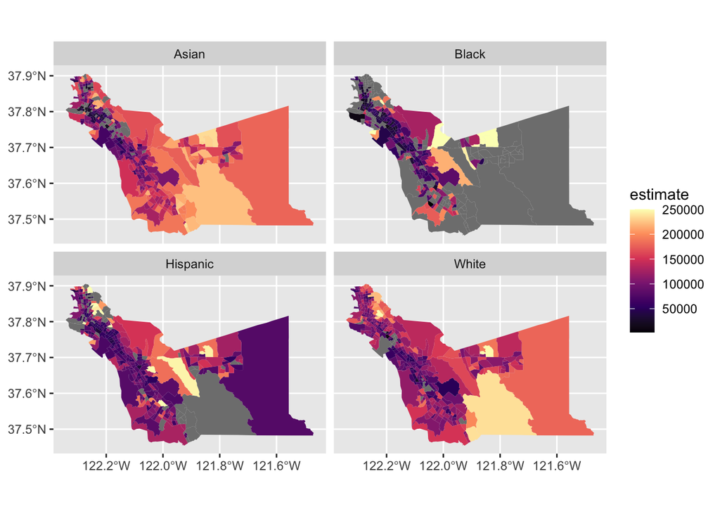

```r
# Create the map
medhhinc_facet_map <- alco_mhhinc_by_race %>%
                        ggplot(aes(fill = estimate)) +
                          facet_wrap(~variable) +
                          geom_sf(color=NA) +
                          scale_fill_viridis_c(option="magma")

# Display the map
medhhinc_facet_map
```

## Challenge

Make a ggplot map of MEDIAN GROSS RENT in San Francisco County by tract using data from the ACS 2015—2019 5-year product.

```r
# Fill in the code to fetch the data - (Solutions.R has the code)

# Median household rent for San Francisco County
alcc_medrent <- get_acs(geography= ,
                              variables= ,
                              year = ,
                              state= ,
                              county= ,
                              geometry=)
```

# Interactive Mapping

## Interactive Mapping

Interactive mapping gives the RStudio environment some of the functionality of desktop GIS.

There are a number of R packages tat you can use, including:

- [mapview](https://r-spatial.github.io/mapview/): quick interactive exploratory data viewing
- [tmap](https://cran.r-project.org/web/packages/tmap/vignettes/tmap-getstarted.html): great static and interactive maps
- [Leaflet](https://rstudio.github.io/leaflet/): highly customizable interactive maps

*All of these are based on the Leaflet Javascript Library.*

## Mapview

Let’s use mapview to make some quick interactive maps of our median hhousehold income data

```r
mapview(alco_mhhincome)
```

## Interactive Choropleth Map

```r
mapview(alco_mhhincome, zcol="estimate")
```

## Challenge

Use `mapview` to create an interactive choropleth map of median household rent.

```r
#Use mapview to create a map of median household income (`alcc_medrent`).
# Your code here - See Solutions.R for code.
```

# Any Questions?

## Figuring out the ACS Variables to use

ACS variables can be confusing.

Some ways to identify the best variables to explore:

- Web search, especially Census web resources, can help.
- The Census Reporter website (https://censusreporter.org) provides another tool for navigating topics, tables, and variable names.
- The NHGIS website (nhgis.org) is a great way to browse variables of interest.

## Margins of Error (MOE)

We haven’t talked about it but it may be important in your work with ACS data.

Math is needed to combine MOEs when you combine variables.

- `tidycensus` includes some nice [functions](https://walker-data.com/tidycensus/articles/margins-of-error.html) for these calculations and a good overview of the topic.

## Summary

`tidycensus` offers two key functions for fetching census tabular and geographic: **get_acs** and **get_decennial**.

- The **load_variables** function helps identify the names of census variables of interest.

Support for fetching `population estimates` and `migration flow` census data was recently added to tidycensus. You can read up on it on the [tidycensus documentation website](https://walker-data.com/tidycensus/articles/other-datasets.html)

Using `tidycensus` to fetch the tabular data or both tabular and geographic data is IMO way easier than any alternatives, **IF** you (1) know R, (2) know a bit about working with geographic data in R.

This approach is also scaleable if you want multiple census variables for various locations and tabulation areas.

You can greatly enhance your maps if you make them with `ggplot2` rather than the default `plot` command.

Interactive mapping greatly enhances your ability to do exploratory data analysis in RStudio.

# References

Much of this tutorial is based on resources by Kyle Walker, author of `tidycensus`. See:

- [tidycensus webpage](https://walker-data.com/tidycensus/index.html))
- [Analyzing the US Census with R](https://walker-data.com/census-r), an online book.

Related D-Lab Workshops

- [R Fundamentals](https://github.com/dlab-berkeley/R-Fundamentals)
- [Geospatial Data in R, parts 1, 2, & 3](https://github.com/dlab-berkeley/R-Geospatial-Fundamentals)

Great online resource for working with spatial data in R

- [Geocomputation with R](https://geocompr.robinlovelace.net/)

# Appendix

## A More Complex Query

Let’s use the 2010 census data to map the percent of San Francisco (SF) properties that were rented.

To start, identify the variables for the

- Total number of housing units
- Number of renter occupied units

## Complete the query

```r
sf_rented <- get_decennial(geography =  ,  # census tabulation unit
                           variables =   , # number of households rented
                           year =  ,
                           summary_var = ,  # Total households
                           state=,
                           county=,
                           geometry=)
```

## and here it is SF Percent Rented Units, 2010

```r
sf_rented <- get_decennial(geography = "tract",  # census tabulation unit
                           variables =  "H004004", #number of households rented
                           year = 2010,
                           summary_var = "H004001",  # Total households
                           state='CA',
                           county='San Francisco',
                           geometry=T)

# take a look at the output
head(sf_rented)
```

[output not shown]

## Calculate Percent Rented

```r
sf_pct_rented <- sf_rented[sf_rented$value > 0,] %>%
                 mutate(pct = 100 * (value / summary_value))

# Take a look
head(sf_pct_rented)
```

[output not shown]

## Map the result

```r
plot(sf_pct_rented['pct'])
```

[output not shown]